# Group Project 1: Flight Delays and Cancellations

### 1. Introduction to the Dataset

The U.S. Department of Transportation's (DOT) [Buereau of Transportation Statistics](https://www.bts.gov/) tracks the performance of domestic flights operated by large airline carriers.

In this project we will work with [dataset](https://www.kaggle.com/usdot/flight-delays) compiled by Kaggle providing the summary information on the number of on-time, delayed, canceled, and diverted flights published by DOT's montly Air Travel Consumer [Report](https://www.transportation.gov/airconsumer/air-travel-consumer-reports) and the Kaggle has compiled this dataset for the year of 2015, flight delays and cancellations.

#### 1.1 Acknowledgements

[Kaggle](https://www.kaggle.com) and DOT's Bureau of Transportation Statistics.

### 2. Dataset and [Data Dictionary](https://www.kaggle.com/usdot/flight-delays/data)

The raw dataset is included as three files: airlines.csv, airports.csv, flights_20_perc.csv in the data folder. Use the [link](https://www.kaggle.com/usdot/flight-delays/data) to get an understanding of the column metadata for each of the files used in the data.

Also, note that the file (flights_20_perc.csv) only contains 20% random sample of the oringal data available on Kaggle. It still has information of 1M flights. This reduction was done to facilitate new programmers working with data files with manageable sizes.

### 3. Project Details

Flight delays and cancellations are typical problems all of us face when traveling. The airports and airline industry try to do everything they can to minimize the impact on the customers and improve their experience. On the other the airline industry also optimizes the flights effectively to fly through their network of cities. That is, for example, a flight from Seattle flies to Chicago, and then further is scheduled to fly from Chicago to New York City. As a result of this efficient utilization of the flights, a popular belief among travelers is that **the flight delays (and cancellations) happen as the day progresses**. Though it seems intuitive, we as data scientists will always look at data to confirm our intuitions. Remember, *"In God we trust; all others bring data."*

#### 3.1 Main Goals

Use the data to prove or disprove the following claims.

1. Do flight delays happen more often later in the day compared to earlier in the day?
2. Does the response to Claim 1 depend on the month of the year?
3. Does the response to Claim 1 depend on the airline? Which airlines have this phenomenon more pronounced and less pronounced?
4. Do flight cancellation happen more often later in the day than earlier in the day?
5. Does the response to Claim 4 depend on the month of the year and on the airline?
6. State based analysis: What are the top three states with lowest average flight delay? What are the top three states with highest average flight delay? Come up with qualitative (and/or quantitative) reason for why you think these states are lowest and highest flight delays.
7. Taxi time in the flight is most frustrating experience to me. Can you let me know which airports I should avoid and which ones I should prefer? Answer this based on average taxi time (both taxi in and taxi out)?

#### Hint:

Some of the questions above require understanding of Group By in Pandas. For example, group by hour of the day or month or airline, etc, and aggregating various informations that will support your arguments.

#### 3.2 Important Notes

1. I do not know if any of the above phenomenon are true in the data I provided. So, do not only attempt to prove them, you could disprove them as well. There is no one right answer. Your responses are graded based on the strength of the arguments and validity of your analysis to prove your points with the data.
2. In order to prove or disprove each of the above claim, do the analysis with the data. After your analysis, write short report for each question referring your analysis in your report.
3. The data (flights_20_perc.csv) is still a **large data file**. You will have to learn (which operations create a copy of the DataFrame, which operations just manipulate existing DataFrame) to work with the large amount of data without requiring too much memory.
   - Most importantly, learn how to use the keyword argument `inplace=True`. In this way you are modifying the existing `DataFrame` rather than create a copy.

### 4. Bonus: An open ended exploration

We investigated above if there is a pattern that the delays in the flights happen more often as the day progresses. **Explore and find more interesting patterns (not necessarily based on delays or cancellations) from the data.** This bonus question is only to pick your analytical and creative mind. Further, it should also give you an experience of a side project. Though, this data (airlines.csv, flights_20_perc.csv, airports.csv) is your primary data, you may chose to combine other supplementary datasets for your analysis.

I recommend to work on this bonus part only after finishing the required analysis above and **do not** over spend time on this bonus question.

Only **top 8 teams** with the most interesting findings will get this additional bonus points. Judgement will be made on correctness, innovativeness/creativeness, strength of the argument, and the rigor in the data analysis. **These bonus points for the top 8 teams will be added to improve your choice of ICA 1 or ICA 2 scores. Please mark clearly at the beginning of the bonus question, whether you want ICA 1 or ICA 2 scores improved,** if no choice is provided, I'll improve the lowest of these two scores.

### 5. Submission Expectations and Requirements

1. **Project report**: I recommend to write your report using Markdown cells in Jupyter Notebook. In that way, you can combine your data analysis (Python code) and your report. Altneratively, you can write your report in Microsoft Word, however, make sure you refer your data analysis appropriately while making your arguments. If you are using Microsoft Word, you can upload the word document in your workspace, using 'Upload' button on the top right corner.
2. **Jupyter notebook** with your entire Python code and data analysis that you have done. It should *only* contain the analysis (Python code) that is used to make arguments in your project report. Points are allocated for neatness of Jupyter Notebooks. Also, you have to make sure the analysis is reproducible, that is, the grader should be able run your notebook to reproduce your results.

#### 5.1 Submission files

Two possible ways

1. **Report using Jupter Notebook:** If you choose to write your report using Markdown in Jupyter Notebook, then you need to just submit one Jupyter notebook that includes both your analysis (Python code) and report. Use headings in Markdown to clearly distinguish between your report and Python code.
2. **Report using Microsoft Word:** If you choose to write your report using Microsoft Word, make sure you submit both the data analysis (Python code) written in Jupyter Notebook and the Microsoft Word document.

Introduction:

Traveling by air has really changed the way we transport ourselves in the world. We can hop on a flight and end up wherever around the world, and all it takes is to get on that flight, right? Well, not really. Flying is easy, you just sit on the plane for a couple hours and then you hopefully reach your target. The annoying part with flying mainly consist of the arrangements around it with flight delays, technical issues, overfull planes, and cancellations. These are typical problems all of us face when traveling. This project report will provide a deepdive into the U.S. flying industry, and more specifically, it will focus on delays and cancellations with regards to air traveling based on a historical dataset from 2015, with the purpose of generating actionable insights and understanding of the flying industry.

Data collection: In this project, the datasets that are being used for analysis are coming from The U.S. Department of Transportation and includes public data about U.S. airline industry. The three specific datasets that will be used for this project include information about IATA airline and airport codes and names that will all be relevant to this analysis. To make these csv files suitable for analysis they were converted into pandas DataFrame's upon being uploaded.

Introduction:

Traveling by air has changed the way we transport ourselves in the world. We can hop on a flight and end up wherever around the world, and all it takes is to get on that flight. Well, not really. Flying is easy. You sit on the plane for a couple of hours, and then you hopefully reach your target. The annoying part with flying mainly consists of the arrangements around it with flight delays, technical issues, overfull planes, and cancellations. These are typical problems all of us face when traveling. This project report will provide a deep-dive into the U.S. flying industry, and more specifically, it will focus on delays and cancellations with regards to air traveling based on a historical dataset from 2015, to generate actionable insights and understanding of the flying industry.

Data collection: In this project, the datasets that are used for this analysis are coming from The U.S. Department of Transportation and include public data about the U.S. airline industry. The three specific datasets that will be used for this project include information about IATA airline and airport codes and names that will all be relevant to this analysis. To make these csv files suitable for analysis, they were converted into pandas DataFrame's upon being uploaded.

```python
import pandas as pd
import numpy as np

airlines = pd.read_csv("../resource/asnlib/publicdata/airlines.csv")
airports = pd.read_csv("../resource/asnlib/publicdata/airports.csv")
flights  = pd.read_csv("../resource/asnlib/publicdata/flights_20_perc.csv")
```

```python
import matplotlib as mpl
import matplotlib.pyplot as plt
import seaborn as sns
plt.style.use('seaborn-poster')
%matplotlib inline
```

Data Exploration and Analysis: In order to better understand the datasets, I performed some initial exploratory analysis to make sense of the numbers. Understanding the data is crucial before jumping into the analysis, and it can help you understand where to focus your efforts on analyzing the most relevant data.

Flights dataset: The describe() function computes a summary of statistics of the columns within the DataFrame. Here I use it to summarize the values in order to show as much information as possible about the dataset, and gaining potentially valuable information. One inital concerns is whether all these missing will be a problem for my analysis. Now when I know that we have missing values, it can be useful to know where they are and how many they are. To find that out, I used the flights.isnull().sum() function to summarize all the missing values by the variables, the output shows us that we probably don't have to care about these missing values, which is good to know.

Airlines dataset: The airlines dataset is much more clean and simple, it only consist of 2 columns, and there are no missing values in the dataset. Moreover, they are 14 different Airlines included in the dataset, and Southwest is the most frequent flyer.

Airports dataset: The airports dataset is clean as well, it consist of six columns, and with a total of 6 missing values for longitude and latitude. I also ranked the states by the amount of airports they have to understand where most of the flights are occuring acorss the U.S.

Upon inital data analysis it seems like we do not need to do any data preprocessing, meaning that our data is clean and ready for analysis!

Data Exploration and Analysis: In order to better understand the datasets, I performed some initial exploratory analysis to make sense of the numbers. Understanding the data is crucial before jumping into the analysis, and it can help you understand where to focus your efforts on analyzing the most relevant data. Flights dataset: The describe() function computes a summary of statistics of the columns within the DataFrame. Here I use it to summarize the values to show as much information as possible about the dataset and gaining potentially valuable information. One initial concern is whether all these missing will be a problem for my analysis. Now when I know that we have missing values, it can be useful to know where they are and how many they are. To find that out, I used the flights.isnull().sum() function to summarize all the missing values by the variables; the output shows us that we probably don't have to care about these missing values, which is good to know. Airlines dataset: The airlines dataset is much more clean and straightforward, it only consists of two columns, and there are no missing values in the dataset. Moreover, they are 14 different Airlines included in the dataset, and Southwest is the most frequent flyer. Airports dataset: The airports dataset is clean as well, it consists of six columns, and with a total of 6 missing values for longitude and latitude. I also ranked the states by the number of airports they have to understand where most of the flights are occurring across the U.S. Upon initial data analysis, it seems like we do not need to do any data preprocessing, meaning that our data is clean and ready for analysis!

```python
# Flights Dataset

flights.describe(include='all') # function to describe dataset
```

|  | YEAR | MONTH | DAY | DAY_OF_WEEK | AIRLINE | FLIGHT_NUMBER | TAIL_NUMBER | ORIGIN_AIRPORT | DESTINATION_AIRPORT | SCHEDULED_DEPARTURE | ... | ARRIVAL_TIME | ARRIVAL_DELAY | DIVERTED | CANCELLED | CANCELLATION_REASON | AIR_SYSTEM_DELAY | SECURITY_DELAY | AIRLINE_DELAY | LATE_AIRCRAFT_DELAY | WEATHER_DELAY |
| --- | --- | --- | --- | --- | --- | --- | --- | --- | --- | --- | --- | --- | --- | --- | --- | --- | --- | --- | --- | --- | --- |
| count | 1163815.0 | 1.163815e+06 | 1.163815e+06 | 1.163815e+06 | 1163815 | 1.163815e+06 | 1160938 | 1163815 | 1163815 | 1.163815e+06 | ... | 1.145454e+06 | 1.143018e+06 | 1.163815e+06 | 1.163815e+06 | 17834 | 212652.000000 | 212652.000000 | 212652.000000 | 212652.000000 | 212652.000000 |
| unique | NaN | NaN | NaN | NaN | 14 | NaN | 4856 | 627 | 628 | NaN | ... | NaN | NaN | NaN | NaN | 4 | NaN | NaN | NaN | NaN | NaN |
| top | NaN | NaN | NaN | NaN | WN | NaN | N480HA | ATL | ATL | NaN | ... | NaN | NaN | NaN | NaN | B | NaN | NaN | NaN | NaN | NaN |
| freq | NaN | NaN | NaN | NaN | 252286 | NaN | 761 | 69098 | 69546 | NaN | ... | NaN | NaN | NaN | NaN | 9633 | NaN | NaN | NaN | NaN | NaN |
| mean | 2015.0 | 6.519455e+00 | 1.571188e+01 | 3.926408e+00 | NaN | 2.171961e+03 | NaN | NaN | NaN | 1.328679e+03 | ... | 1.476349e+03 | 4.448477e+00 | 2.545937e-03 | 1.532374e-02 | NaN | 13.401299 | 0.080662 | 19.074460 | 23.620784 | 2.971301 |
| std | 0.0 | 3.404023e+00 | 8.781824e+00 | 1.989473e+00 | NaN | 1.757754e+03 | NaN | NaN | NaN | 4.834849e+02 | ... | 5.259004e+02 | 3.959621e+01 | 5.039303e-02 | 1.228370e-01 | NaN | 27.789444 | 2.266766 | 49.386428 | 43.305600 | 20.768194 |
| min | 2015.0 | 1.000000e+00 | 1.000000e+00 | 1.000000e+00 | NaN | 1.000000e+00 | NaN | NaN | NaN | 1.000000e+00 | ... | 1.000000e+00 | -8.100000e+01 | 0.000000e+00 | 0.000000e+00 | NaN | 0.000000 | 0.000000 | 0.000000 | 0.000000 | 0.000000 |
| 25% | 2015.0 | 4.000000e+00 | 8.000000e+00 | 2.000000e+00 | NaN | 7.280000e+02 | NaN | NaN | NaN | 9.160000e+02 | ... | 1.059000e+03 | -1.300000e+01 | 0.000000e+00 | 0.000000e+00 | NaN | 0.000000 | 0.000000 | 0.000000 | 0.000000 | 0.000000 |
| 50% | 2015.0 | 7.000000e+00 | 1.600000e+01 | 4.000000e+00 | NaN | 1.687000e+03 | NaN | NaN | NaN | 1.325000e+03 | ... | 1.512000e+03 | -5.000000e+00 | 0.000000e+00 | 0.000000e+00 | NaN | 2.000000 | 0.000000 | 2.000000 | 3.000000 | 0.000000 |
| 75% | 2015.0 | 9.000000e+00 | 2.300000e+01 | 6.000000e+00 | NaN | 3.228000e+03 | NaN | NaN | NaN | 1.730000e+03 | ... | 1.916000e+03 | 8.000000e+00 | 0.000000e+00 | 0.000000e+00 | NaN | 17.000000 | 0.000000 | 19.000000 | 29.000000 | 0.000000 |
| max | 2015.0 | 1.200000e+01 | 3.100000e+01 | 7.000000e+00 | NaN | 9.855000e+03 | NaN | NaN | NaN | 2.359000e+03 | ... | 2.400000e+03 | 1.971000e+03 | 1.000000e+00 | 1.000000e+00 | NaN | 1134.000000 | 241.000000 | 1971.000000 | 990.000000 | 1211.000000 |

11 rows × 31 columns

```python
flights.isnull().sum() # find missing values
```

```
YEAR                         0
MONTH                        0
DAY                          0
DAY_OF_WEEK                  0
AIRLINE                      0
FLIGHT_NUMBER                0
TAIL_NUMBER               2877
ORIGIN_AIRPORT               0
DESTINATION_AIRPORT          0
SCHEDULED_DEPARTURE          0
DEPARTURE_TIME           17093
DEPARTURE_DELAY          17093
TAXI_OUT                 17673
WHEELS_OFF               17673
SCHEDULED_TIME               0
ELAPSED_TIME             20797
AIR_TIME                 20797
DISTANCE                     0
WHEELS_ON                18361
TAXI_IN                  18361
SCHEDULED_ARRIVAL            0
ARRIVAL_TIME             18361
ARRIVAL_DELAY            20797
DIVERTED                     0
CANCELLED                    0
CANCELLATION_REASON    1145981
AIR_SYSTEM_DELAY        951163
SECURITY_DELAY          951163
AIRLINE_DELAY           951163
LATE_AIRCRAFT_DELAY     951163
WEATHER_DELAY           951163
dtype: int64
```

```python
flights['AIRLINE'].value_counts() # find number of trips for each airline
```

```
WN    252286
DL    174951
AA    144781
OO    117242
EV    114682
UA    103647
MQ     59195
B6     53365
US     39617
AS     34624
NK     23520
F9     18104
HA     15257
VX     12544
Name: AIRLINE, dtype: int64
```

```python
# Airlines dataset

airlines.describe(include='all')
```

|  | IATA_CODE | AIRLINE |
| --- | --- | --- |
| count | 14 | 14 |
| unique | 14 | 14 |
| top | B6 | United Air Lines Inc. |
| freq | 1 | 1 |

```python
airlines.isnull().sum() # find missing values, zero missing values which is good to know
```

```
IATA_CODE    0
AIRLINE      0
dtype: int64
```

```python
airlines['AIRLINE'].value_counts().sum() # find total number of airlines
```

```
14
```

```python
# Airports dataset

airports.head()
```

|  | IATA_CODE | AIRPORT | CITY | STATE | COUNTRY | LATITUDE | LONGITUDE |
| --- | --- | --- | --- | --- | --- | --- | --- |
| 0 | ABE | Lehigh Valley International Airport | Allentown | PA | USA | 40.65236 | -75.44040 |
| 1 | ABI | Abilene Regional Airport | Abilene | TX | USA | 32.41132 | -99.68190 |
| 2 | ABQ | Albuquerque International Sunport | Albuquerque | NM | USA | 35.04022 | -106.60919 |
| 3 | ABR | Aberdeen Regional Airport | Aberdeen | SD | USA | 45.44906 | -98.42183 |
| 4 | ABY | Southwest Georgia Regional Airport | Albany | GA | USA | 31.53552 | -84.19447 |

```python
airports.describe(include='all')
```

|  | IATA_CODE | AIRPORT | CITY | STATE | COUNTRY | LATITUDE | LONGITUDE |
| --- | --- | --- | --- | --- | --- | --- | --- |
| count | 322 | 322 | 322 | 322 | 322 | 319.000000 | 319.000000 |
| unique | 322 | 322 | 308 | 54 | 1 | NaN | NaN |
| top | BTV | Baton Rouge Metropolitan Airport | Springfield | TX | USA | NaN | NaN |
| freq | 1 | 1 | 2 | 24 | 322 | NaN | NaN |
| mean | NaN | NaN | NaN | NaN | NaN | 38.981244 | -98.378964 |
| std | NaN | NaN | NaN | NaN | NaN | 8.616736 | 21.523492 |
| min | NaN | NaN | NaN | NaN | NaN | 13.483450 | -176.646030 |
| 25% | NaN | NaN | NaN | NaN | NaN | 33.652040 | -110.839385 |
| 50% | NaN | NaN | NaN | NaN | NaN | 39.297610 | -93.403070 |
| 75% | NaN | NaN | NaN | NaN | NaN | 43.154675 | -82.722995 |
| max | NaN | NaN | NaN | NaN | NaN | 71.285450 | -64.798560 |

```python
airports.isnull().sum() # find missing values, only a couple missing values which is good to know
```

```
IATA_CODE    0
AIRPORT      0
CITY         0
STATE        0
COUNTRY      0
LATITUDE     3
LONGITUDE    3
dtype: int64
```

```python
airports['STATE'].value_counts() # find number of airports by state
```

```
TX    24
CA    22
AK    19
FL    17
MI    15
NY    14
CO    10
PA     8
MN     8
NC     8
WI     8
ND     8
MT     8
IL     7
VA     7
GA     7
LA     7
WY     6
ID     6
AL     5
OH     5
MS     5
MA     5
MO     5
TN     5
HI     5
UT     5
IA     5
OR     5
AR     4
WA     4
IN     4
KY     4
KS     4
NM     4
SC     4
AZ     4
NV     3
NJ     3
SD     3
PR     3
OK     3
NE     3
VI     2
ME     2
RI     1
WV     1
MD     1
GU     1
CT     1
NH     1
VT     1
AS     1
DE     1
Name: STATE, dtype: int64
```

Question 1: Do flights delays happen more often later in the day compared to earlier in the day?

To solve this problem, I had to split the 24 hours of the day into subcategories to represent different periods of the day and create a new column: Early morning, Late morning, Early afternoon, Late Afternoon, Early Evening, Late Evening, and Night. The new column called 'TIME_OF_DAY' is added to the original flights dataset. After creating this new column, we can perform some analysis on the column and quickly get some useful insights that tell us that most flights take-off in the morning and afternoon. Moreover, we can also get the normalized values, which tells us that around ~80% of all flights depart in the morning or afternoon, meaning that these hours probably will have more delays. However, just assuming this is not good enough for a data scientist, so I called a function to find total time delayed by the time of the day, and the output showed me that my intuition was right pretty good. Whereas, most flights are delayed in the afternoon or early evening. During the late afternoon is when the most flights are delayed, followed by early evening and late afternoon. This information gives us some potentially useful insights for future references in case I'm looking to travel by air. The best time of the day to fly if you want a smooth and efficient experience seems to be in the morning time considering they have a lot of flights taking off, but not that many are late. However, if you want to try to make sure you are not late, you should probably schedule Night and Late evening flights, considering they have the lowest amount of delayed flights.

Flights are the least delayed at night and late evening, according to my analysis. However, this can be misrepresentative, considering that there are way fewer flights taking off during the later periods of the day. However, the most frequent delays still appear to occur after noon, considering that the top 3 time periods with the most amount of minutes delayed are: Late Afternoon, Early Evening, Early Afternoon. So yes, the majority of delayed flights will happen in the afternoon.

```python
# 1. Do flights delays happen more often later in the day compared to earlier in the day?

# Function that separates the day into 7 different categories and creates a new colum:
# Early morning
# Late morning
# Early afternoon
# Late Afternoon
# Early Evening
# Late Evening
# Night

def get_time_of_day(SCHEDULED_DEPARTURE):
    if SCHEDULED_DEPARTURE < 900 and SCHEDULED_DEPARTURE >= 500:
        return 'EARLY MORNING'
    elif SCHEDULED_DEPARTURE < 1200 and SCHEDULED_DEPARTURE >= 900:
        return 'LATE MORNING'
    elif SCHEDULED_DEPARTURE < 1500 and SCHEDULED_DEPARTURE >= 1200:
        return 'EARLY AFTERNOON'
    elif SCHEDULED_DEPARTURE < 1800 and SCHEDULED_DEPARTURE >= 1500:
        return 'LATE AFTERNOON'
    elif SCHEDULED_DEPARTURE < 2100 and SCHEDULED_DEPARTURE >= 1800:
        return 'EARLY EVENING'
    elif SCHEDULED_DEPARTURE < 2300 and SCHEDULED_DEPARTURE >= 2000:
        return 'LATE EVENING'
    else:
        return 'NIGHT'

flights['TIME_OF_DAY'] = flights['SCHEDULED_DEPARTURE'].apply(get_time_of_day)
```

```python
flights.head() # the column has been added to the flights datasets
```

|  | YEAR | MONTH | DAY | DAY_OF_WEEK | AIRLINE | FLIGHT_NUMBER | TAIL_NUMBER | ORIGIN_AIRPORT | DESTINATION_AIRPORT | SCHEDULED_DEPARTURE | ... | ARRIVAL_DELAY | DIVERTED | CANCELLED | CANCELLATION_REASON | AIR_SYSTEM_DELAY | SECURITY_DELAY | AIRLINE_DELAY | LATE_AIRCRAFT_DELAY | WEATHER_DELAY | TIME_OF_DAY |
| --- | --- | --- | --- | --- | --- | --- | --- | --- | --- | --- | --- | --- | --- | --- | --- | --- | --- | --- | --- | --- | --- |
| 0 | 2015 | 12 | 9 | 3 | AA | 1445 | N860AA | SAN | DFW | 1430 | ... | -2.0 | 0 | 0 | NaN | NaN | NaN | NaN | NaN | NaN | EARLY AFTERNOON |
| 1 | 2015 | 1 | 24 | 6 | DL | 2134 | N124DE | MSP | PHX | 1120 | ... | -22.0 | 0 | 0 | NaN | NaN | NaN | NaN | NaN | NaN | LATE MORNING |
| 2 | 2015 | 8 | 12 | 3 | DL | 1429 | N607AT | TUL | ATL | 1237 | ... | -11.0 | 0 | 0 | NaN | NaN | NaN | NaN | NaN | NaN | EARLY AFTERNOON |
| 3 | 2015 | 2 | 24 | 2 | OO | 7398 | N565SW | SLC | VEL | 1705 | ... | -15.0 | 0 | 0 | NaN | NaN | NaN | NaN | NaN | NaN | LATE AFTERNOON |
| 4 | 2015 | 2 | 6 | 5 | MQ | 2948 | N3AEMQ | AMA | DFW | 1958 | ... | 0.0 | 0 | 0 | NaN | NaN | NaN | NaN | NaN | NaN | EARLY EVENING |

5 rows × 32 columns

```python
time_of_day_count = flights['TIME_OF_DAY'].value_counts() # understanding what time of the day most flights depart
time_of_day_count
```

```
EARLY MORNING      260497
LATE AFTERNOON     219299
LATE MORNING       216553
EARLY AFTERNOON    209364
EARLY EVENING      184188
LATE EVENING        60488
NIGHT               13426
Name: TIME_OF_DAY, dtype: int64
```

```python
time_of_day_perc = flights['TIME_OF_DAY'].value_counts(normalize=True) * 100 # getting the percentages
time_of_day_perc
```

```
EARLY MORNING      22.383025
LATE AFTERNOON     18.843115
LATE MORNING       18.607167
EARLY AFTERNOON    17.989457
EARLY EVENING      15.826227
LATE EVENING        5.197390
NIGHT               1.153620
Name: TIME_OF_DAY, dtype: float64
```

```python
time_of_day_group = flights.groupby(['TIME_OF_DAY'])
time_of_day_group
```

```
<pandas.core.groupby.groupby.DataFrameGroupBy object at 0x7fefc0310c88>
```

```python
# finding time delayed by time of day

finding_time_delayed_by_time_of_day = time_of_day_group[['DEPARTURE_DELAY']].sum().sort_values('DEPARTURE_DELAY')
finding_time_delayed_by_time_of_day
```

| TIME_OF_DAY | DEPARTURE_DELAY |
| --- | --- |
| NIGHT | 119978.0 |
| LATE EVENING | 759054.0 |
| EARLY MORNING | 843495.0 |
| LATE MORNING | 1468267.0 |
| EARLY AFTERNOON | 2041853.0 |
| EARLY EVENING | 2738143.0 |
| LATE AFTERNOON | 2834720.0 |

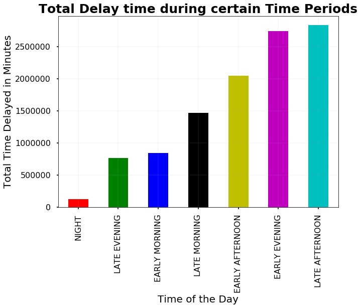

```python
# Visualization

figure, axes = plt.subplots(figsize=(10,7))

my_colors = 'rgbkymc'

finding_time_delayed_by_time_of_day.plot(ax=axes, kind='bar', stacked=True, color=my_colors)

axes.get_legend().remove()
axes.set_ylabel('Total Time Delayed in Minutes', fontsize=20)
axes.set_xlabel('Time of the Day', fontsize=20)
axes.set_title('Total Delay time during certain Time Periods', fontsize=25, fontweight='bold')
axes.grid(alpha=.1)
```

Question 2: Does the response to claim 1 depend on the month of the year?

My response to claim 1, about how flights are more delayed in the afternoon does, in fact, seem to depend on the month of the year. To reach this conclusion, I had to create a visualization representing how delays are different in the AM versus in the PM. As we can see from this visual representation, the most amount of delays occur in frequent air traveling periods during the summer month from May to August, and also during the holiday season in December. The line chart shows how the total amount of time-delayed differs by AM and PM, and by the month of the year. It is interesting to see that the total time delayed for PM is higher than AM for every month, which is a good enough indicator to back my answer that most flights are delayed in the afternoon.

```python
# Question 2:
# Does the response to claim 1 depend on the month of the year?

# Split day in half to create AM and PM

def split_day(SCHEDULED_DEPARTURE):
    if SCHEDULED_DEPARTURE <= 1200 and SCHEDULED_DEPARTURE >=0:
        return 'AM'
    else:
        return 'PM'
flights['AM/PM'] = flights['SCHEDULED_DEPARTURE'].apply(split_day)
```

```python
# Comparing AM and PM total flights

AM_PM_distribution = flights['AM/PM'].value_counts()
AM_PM_distribution
```

```
PM    675397
AM    488418
Name: AM/PM, dtype: int64
```

```python
# Getting the percentages:

AM_PM_perc_distribution = flights['AM/PM'].value_counts(normalize=True) * 100
AM_PM_perc_distribution
```

```
PM    58.033021
AM    41.966979
Name: AM/PM, dtype: float64
```

```python
AM_PM_by_month = flights.groupby(['AM/PM', 'MONTH'])

# Summary statistics output to better understand the difference between AM and PM flights
AM_PM_by_month[['DEPARTURE_DELAY']].describe()

# Getting the total delay by each month by AM and PM
delay_AM_PM_by_month = AM_PM_by_month[['DEPARTURE_DELAY']].sum()
delay_AM_PM_by_month
```

| AM/PM | MONTH | DEPARTURE_DELAY |
| --- | --- | --- |
| AM | 1 | 222200.0 |
|  | 2 | 268800.0 |
|  | 3 | 246388.0 |
|  | 4 | 163940.0 |
|  | 5 | 178515.0 |
|  | 6 | 285619.0 |
|  | 7 | 218245.0 |
|  | 8 | 201860.0 |
|  | 9 | 63165.0 |
|  | 10 | 100457.0 |
|  | 11 | 158318.0 |
|  | 12 | 292496.0 |
| PM | 1 | 669924.0 |
|  | 2 | 712103.0 |
|  | 3 | 720848.0 |
|  | 4 | 591101.0 |
|  | 5 | 762920.0 |
|  | 6 | 1128123.0 |
|  | 7 | 950012.0 |
|  | 8 | 808867.0 |
|  | 9 | 372137.0 |
|  | 10 | 384637.0 |
|  | 11 | 500985.0 |
|  | 12 | 803850.0 |

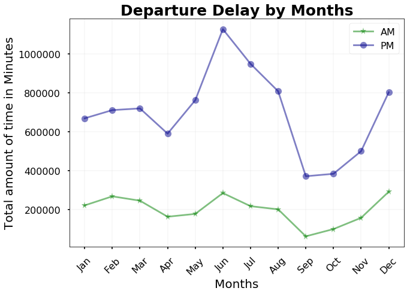

```python
# Visualization

delay_AM = delay_AM_PM_by_month.loc['AM']
delay_PM = delay_AM_PM_by_month.loc['PM']

figure, axes = plt.subplots(figsize=(10,7))

axes.plot(delay_AM.index, delay_AM['DEPARTURE_DELAY'], color = 'green', label='AM', marker='*', alpha=.5)
axes.plot(delay_PM.index, delay_PM['DEPARTURE_DELAY'], color='darkblue', label='PM', marker='o', alpha=.5)

axes.set_xticks(range(1,13))
x_lab = ('Jan', 'Feb', 'Mar', 'Apr', 'May', 'Jun', 'Jul', 'Aug', 'Sep', 'Oct'
         , 'Nov', 'Dec')
axes.set_xticklabels(x_lab, rotation=45)

axes.legend()
axes.set_ylabel('Total amount of time in Minutes', fontsize=20)
axes.set_xlabel('Months', fontsize=20)
axes.set_title('Departure Delay by Months', fontsize=25, fontweight='bold')
axes.grid(alpha=.1)
```

Question 3: Does the response to claim 1 depend on the airline? Which airlines have this phenomenon more pronounced and less pronounced?

```python
# Question 3: Does the response to claim 1 depend on the airline? Which airlines have this phenomenon more
#             pronounced and less pronounced?

# Split airlines by AM and PM

airlines_group = flights.groupby(['AM/PM', 'AIRLINE'])
delay_airlines = airlines_group[['DEPARTURE_DELAY']].sum() #total delay in mins

delay_AM_airlines = delay_airlines.loc['AM'] #split up total delay by AM/PM
delay_PM_airlines = delay_airlines.loc['PM']
```

```python
# setting criteria for visualization

# Setting the index
index_length = (range(len(delay_AM_airlines.index)))
index = np.arange(14)

# Calculate the difference
AM_PM_diff_by_airlines = delay_PM_airlines - delay_AM_airlines
AM_PM_diff_by_airlines
```

| AIRLINE | DEPARTURE_DELAY |
| --- | --- |
| AA | 686422.0 |
| AS | 57469.0 |
| B6 | 475338.0 |
| DL | 691374.0 |
| EV | 497082.0 |
| F9 | 121670.0 |
| HA | 19913.0 |
| MQ | 205962.0 |
| NK | 168694.0 |
| OO | 370342.0 |
| UA | 657827.0 |
| US | 154152.0 |
| VX | 62498.0 |
| WN | 1836761.0 |

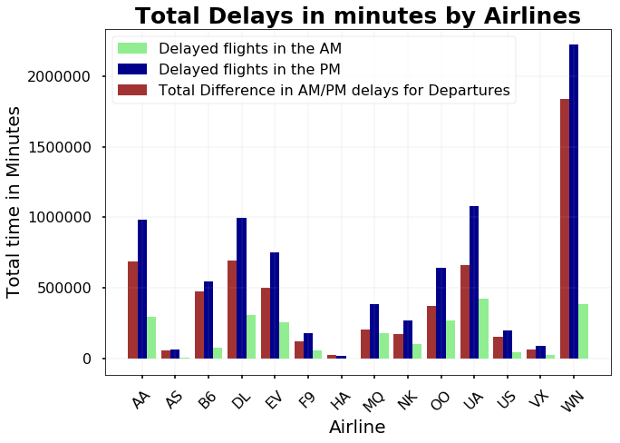

```python
figure, axes = plt.subplots(figsize=(10,7))

width=.28

bar_AM_airlines = axes.bar(index + width, delay_AM_airlines['DEPARTURE_DELAY'],
                           width, color = 'lightgreen', label='Delayed flights in the AM')
bar_PM_airlines = axes.bar(index, delay_PM_airlines['DEPARTURE_DELAY'], width, color = 'darkblue',
                           label='Delayed flights in the PM')
bar_difference_airlines = axes.bar(index - width, AM_PM_diff_by_airlines['DEPARTURE_DELAY'], width, color='darkred', label = 'Total Difference in AM/PM delays for Departures', alpha=.8)

axes.set_xticks(range(0,14))
x_lab2 = ('AA', 'AS', 'B6', 'DL', 'EV', 'F9', 'HA', 'MQ', 'NK', 'OO', 'UA', 'US', 'VX', 'WN')
axes.set_xticklabels(x_lab2, rotation=45)

axes.legend()
axes.set_ylabel('Total time in Minutes', fontsize=20)
axes.set_xlabel('Airline', fontsize=20)
axes.set_title('Total Delays in minutes by Airlines', fontsize=25,
              fontweight='bold')
axes.grid(alpha=.1)
```

Question 4: Do flight cancellation happen more often later in the day than earlier in the day?

Flight cancellation is much more spread out than departure delays over the course of the day. Flights scheduled in the early morning are most frequently cancelled, followed by flights in the late afternoon, and then there early evening coming in on a third place for cancellations. According to my analysis, there is no evidence that there are more cancellation later in the day compared to earlier in the day.

```python
# Question 4: Do flight cancellation happen more often later in the
# day than earlier in the day?

flights['AM/PM']

# function to find number of cancelled flights by time of day
cancellation_AM_PM = time_of_day_group[['CANCELLED']].sum().sort_values('CANCELLED')
cancellation_AM_PM
```

| TIME_OF_DAY | CANCELLED |
| --- | --- |
| NIGHT | 134 |
| LATE EVENING | 1158 |
| LATE MORNING | 2781 |
| EARLY AFTERNOON | 2845 |
| EARLY EVENING | 3456 |
| LATE AFTERNOON | 3490 |
| EARLY MORNING | 3970 |

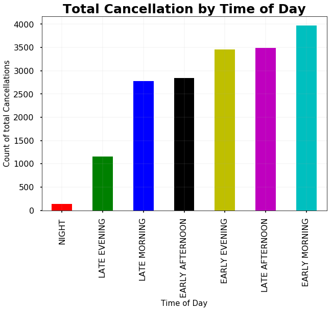

```python
# Visualization

figure, axes = plt.subplots(figsize=(10,7))

cancellation_AM_PM.plot(ax=axes, kind='bar', color=my_colors, label='Total Cancellations by Time of Day')


axes.get_legend().remove()
axes.set_ylabel('Count of total Cancellations', fontsize=15)
axes.set_xlabel('Time of Day', fontsize=15)
axes.set_title('Total Cancellation by Time of Day', fontsize=25, fontweight='bold')
axes.grid(alpha=.1)
```

Question 5: Does the response to Claim 4 depend on the month of the year and the airline?

My claim to question 4 was that there is no evidence that there are more cancellation later in the day compared to earlier in the day. It seems like cancellations happens more frequently during certain months, and especially during the month of February which has much more cancellations compared to other months for some reason. This discovery is something that could be worth looking into, to try to understand this apparent phenomenon.

```python
# Question 5: Does the response to Claim 4 depend on the month of the
# year and the airline?

AM_PM_by_month = flights.groupby(['AM/PM', 'MONTH'])
delay_AM_PM = AM_PM_by_month[['CANCELLED']].sum() # find the total delay by month for AM and PM
delay_AM_PM
```

| AM/PM | MONTH | CANCELLED |
| --- | --- | --- |
| AM | 1 | 1070 |
|  | 2 | 1715 |
|  | 3 | 897 |
|  | 4 | 356 |
|  | 5 | 401 |
|  | 6 | 535 |
|  | 7 | 354 |
|  | 8 | 327 |
|  | 9 | 125 |
|  | 10 | 157 |
|  | 11 | 358 |
|  | 12 | 573 |
| PM | 1 | 1337 |
|  | 2 | 2386 |
|  | 3 | 1284 |
|  | 4 | 542 |
|  | 5 | 761 |
|  | 6 | 1224 |
|  | 7 | 631 |
|  | 8 | 614 |
|  | 9 | 297 |
|  | 10 | 322 |
|  | 11 | 554 |
|  | 12 | 1014 |

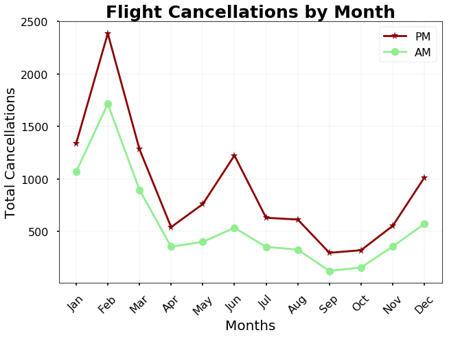

```python
# Visualization

delay_AM2 = delay_AM_PM.loc['AM']
delay_PM2 = delay_AM_PM.loc['PM']

figure, axes = plt.subplots(figsize=(10,7))
axes.plot(delay_PM.index, delay_PM2['CANCELLED'], color = 'darkred',
          label='PM', marker='*')
axes.plot(delay_PM.index, delay_AM2['CANCELLED'], color = 'lightgreen',
          label='AM', marker='o')

axes.set_xticks(range(1,13))
x_lab = ('Jan', 'Feb', 'Mar', 'Apr', 'May', 'Jun', 'Jul', 'Aug', 'Sep', 'Oct'
         , 'Nov', 'Dec')
axes.set_xticklabels(x_lab, rotation=45)

axes.legend()
axes.set_xlabel('Months', fontsize=20)
axes.set_ylabel('Total Cancellations', fontsize=20)
axes.set_title('Flight Cancellations by Month', fontsize=25, fontweight='bold')
axes.grid(alpha=.1)
```

```python
# grouping airlines by AM/PM

cancellation_by_airlines_delay_yes_no = airlines_group['CANCELLED'].value_counts()
cancellation_by_airlines_delay_yes_no # # 1 = Cancelled, 0 = not cancelled

cancellation_by_airlines_norm  = airlines_group['CANCELLED'].value_counts(normalize=True)
cancellation_by_airlines_norm # 1 = Cancelled, 0 = not cancelled

cancellation_AM_by_airlines = cancellation_by_airlines_delay_yes_no.loc['AM']
cancellation_PM_by_airlines = cancellation_by_airlines_delay_yes_no.loc['PM']
cancellation_by_airlines_delay_yes_no
cancellation_AM_by_airlines
```

```
AIRLINE  CANCELLED
AA       0             61924
         1               914
AS       0             15075
         1                48
B6       0             21870
         1               363
DL       0             73181
         1               288
EV       0             45522
         1               971
F9       0              6907
         1                35
HA       0              6571
         1                12
MQ       0             22964
         1              1078
NK       0              9706
         1               135
OO       0             46445
         1               724
UA       0             44454
         1               527
US       0             16907
         1               350
VX       0              5156
         1                48
WN       0            104868
         1              1375
Name: CANCELLED, dtype: int64
```

```python
# df with all cancelled flights
airline_cancellations = airlines_group[['CANCELLED']].sum()

# Create two df for cancelled flights by AM and PM
airline_AM_cancellations = airline_cancellations.loc['AM']
airline_PM_cancellations = airline_cancellations.loc['PM']

# calculating the difference

difference_airline_cancellations = airline_PM_cancellations - airline_AM_cancellations
difference_airline_cancellations
```

| AIRLINE | CANCELLED |
| --- | --- |
| AA | 337 |
| AS | 33 |
| B6 | 141 |
| DL | 165 |
| EV | 1045 |
| F9 | 42 |
| HA | 6 |
| MQ | 822 |
| NK | 145 |
| OO | 590 |
| UA | 230 |
| US | 104 |
| VX | 13 |
| WN | 425 |

```
Text(0.5,1,'Total Cancellations by Airlines in 2015')
```

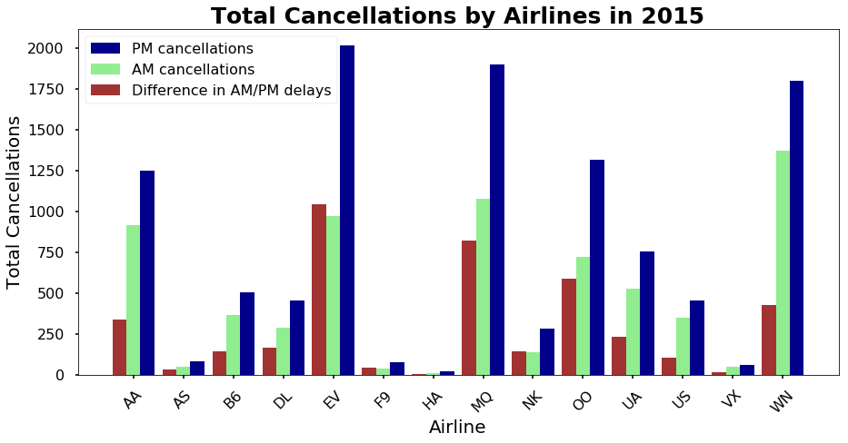

```python
figure, axes = plt.subplots(figsize=(15,7))

width = .28

bar_PM_airlines2 = axes.bar(index + width, airline_PM_cancellations['CANCELLED'],
                           width, color='darkblue', label='PM cancellations')
bar_AM_airlines2 = axes.bar(index, airline_AM_cancellations['CANCELLED'],
                           width, color='lightgreen', label='AM cancellations')
difference_between_AM_PM_bar = axes.bar(index-width, difference_airline_cancellations['CANCELLED'],
                                       width,color='darkred', label='Difference in AM/PM delays',
                                       alpha=.8)
axes.set_xticks(range(0,14))
x_lab2 = ('AA', 'AS', 'B6', 'DL', 'EV', 'F9', 'HA', 'MQ', 'NK', 'OO', 'UA', 'US', 'VX', 'WN')
axes.set_xticklabels(x_lab2, rotation=45)

axes.legend()
axes.set_ylabel('Total Cancellations', fontsize=20)
axes.set_xlabel('Airline', fontsize=20)
axes.set_title('Total Cancellations by Airlines in 2015', fontsize=25,
              fontweight='bold')
```

Question 6:

Come up with qualitative (and/or quantitative) reason for why you think these states are lowest and highest flight delays. My quantitative reasons are explained through my code and my visualization showing these facts. As for qualitative reasons, the three with the highest delay do make sense, considering they are among the most populated cities in the states, and they also have multiple major international airports. As for the States with the lowest average flight delay, those results are not very surprising either considering they are all small states without any big cities or public draw.

```python
merged_airline_flights = pd.merge(flights, airports, right_on='IATA_CODE', left_on='ORIGIN_AIRPORT')

merged_airline_flights.isnull().sum() # find missing values


keep_relevant_columns = merged_airline_flights.filter(['YEAR', 'AIRLINE', 'STATE', 'DEPARTURE_DELAY',
                                                       'IATA_CODE'])
keep_relevant_columns
```

|  | YEAR | AIRLINE | STATE | DEPARTURE_DELAY | IATA_CODE |
| --- | --- | --- | --- | --- | --- |
| 0 | 2015 | AA | CA | -4.0 | SAN |
| 1 | 2015 | WN | CA | 12.0 | SAN |
| 2 | 2015 | WN | CA | -2.0 | SAN |
| 3 | 2015 | WN | CA | 6.0 | SAN |
| 4 | 2015 | UA | CA | -12.0 | SAN |
| 5 | 2015 | WN | CA | 1.0 | SAN |
| 6 | 2015 | VX | CA | 157.0 | SAN |
| 7 | 2015 | WN | CA | 15.0 | SAN |
| 8 | 2015 | DL | CA | -6.0 | SAN |
| 9 | 2015 | WN | CA | 8.0 | SAN |
| 10 | 2015 | OO | CA | -10.0 | SAN |
| 11 | 2015 | WN | CA | 2.0 | SAN |
| 12 | 2015 | AA | CA | 68.0 | SAN |
| 13 | 2015 | AA | CA | -1.0 | SAN |
| 14 | 2015 | AS | CA | -9.0 | SAN |
| 15 | 2015 | UA | CA | 1.0 | SAN |
| 16 | 2015 | WN | CA | -1.0 | SAN |
| 17 | 2015 | WN | CA | 0.0 | SAN |
| 18 | 2015 | WN | CA | -5.0 | SAN |
| 19 | 2015 | DL | CA | -4.0 | SAN |
| 20 | 2015 | F9 | CA | -9.0 | SAN |
| 21 | 2015 | WN | CA | -5.0 | SAN |
| 22 | 2015 | WN | CA | 5.0 | SAN |
| 23 | 2015 | WN | CA | -3.0 | SAN |
| 24 | 2015 | UA | CA | 5.0 | SAN |
| 25 | 2015 | WN | CA | -1.0 | SAN |
| 26 | 2015 | UA | CA | 44.0 | SAN |
| 27 | 2015 | AA | CA | -2.0 | SAN |
| 28 | 2015 | F9 | CA | -5.0 | SAN |
| 29 | 2015 | WN | CA | 18.0 | SAN |
| ... | ... | ... | ... | ... | ... |
| 1067225 | 2015 | AS | AK | -19.0 | ADK |
| 1067226 | 2015 | AS | AK | -15.0 | ADK |
| 1067227 | 2015 | AS | AK | 8.0 | ADK |
| 1067228 | 2015 | AS | AK | 21.0 | ADK |
| 1067229 | 2015 | AS | AK | 18.0 | ADK |
| 1067230 | 2015 | AS | AK | NaN | ADK |
| 1067231 | 2015 | AS | AK | 17.0 | ADK |
| 1067232 | 2015 | AS | AK | -82.0 | ADK |
| 1067233 | 2015 | AS | AK | 7.0 | ADK |
| 1067234 | 2015 | AS | AK | 14.0 | ADK |
| 1067235 | 2015 | AS | AK | 33.0 | ADK |
| 1067236 | 2015 | AS | AK | 44.0 | ADK |
| 1067237 | 2015 | AS | AK | 1.0 | ADK |
| 1067238 | 2015 | AS | AK | 20.0 | ADK |
| 1067239 | 2015 | EV | NY | -4.0 | ITH |
| 1067240 | 2015 | OO | NY | 65.0 | ITH |
| 1067241 | 2015 | OO | NY | 0.0 | ITH |
| 1067242 | 2015 | EV | NY | -2.0 | ITH |
| 1067243 | 2015 | OO | NY | 8.0 | ITH |
| 1067244 | 2015 | OO | NY | -7.0 | ITH |
| 1067245 | 2015 | AS | AK | -24.0 | DLG |
| 1067246 | 2015 | AS | AK | -14.0 | DLG |
| 1067247 | 2015 | AS | AK | -11.0 | DLG |
| 1067248 | 2015 | AS | AK | -13.0 | DLG |
| 1067249 | 2015 | AS | AK | 4.0 | DLG |
| 1067250 | 2015 | AS | AK | -4.0 | DLG |
| 1067251 | 2015 | AS | AK | -22.0 | DLG |
| 1067252 | 2015 | AS | AK | 15.0 | DLG |
| 1067253 | 2015 | AS | AK | -11.0 | DLG |
| 1067254 | 2015 | AS | AK | -23.0 | DLG |

1067255 rows × 5 columns

```python
keep_relevant_columns.isnull().sum()

grouped_values = keep_relevant_columns.groupby(['STATE'])
grouped_values

states_most_delays = grouped_values[['DEPARTURE_DELAY']].sum().sort_values('DEPARTURE_DELAY')
states_most_delays

states_delay_avg = states_most_delays.mean()
states_delay_avg # 191118
```

```
DEPARTURE_DELAY    191118.814815
dtype: float64
```

```
Text(10,200000,'Average Delay across States (191118) mins')
```

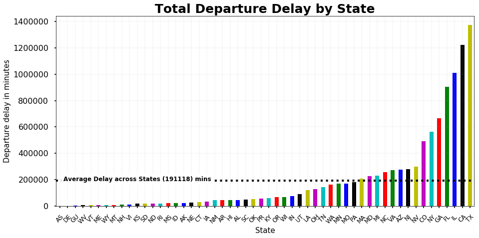

```python
figure, axes = plt.subplots(figsize=(15,7))

states_most_delays.plot(ax=axes, kind='bar', color=my_colors, label='Total Departure Delay by State')

axes.get_legend().remove()
axes.set_ylabel('Departure delay in minutes', fontsize=15)
axes.set_xlabel('State', fontsize=15)
axes.set_title('Total Departure Delay by State', fontsize=25, fontweight='bold')
axes.grid(alpha=.1)
plt.xticks(rotation=45, fontsize=12)
plt.axhline(y=191118 , color='black', linestyle='dotted', linewidth=4)
plt.text(10, 200000, 'Average Delay across States (191118) mins', fontweight='bold',
         fontsize=12, va='center', ha='center', backgroundcolor='w')
```

```python
top3_highest_average_delay = states_most_delays.nlargest(3,'DEPARTURE_DELAY')
top3_highest_average_delay

top3_lowest_average_delay = states_most_delays.nsmallest(3,'DEPARTURE_DELAY')
top3_lowest_average_delay

top3_highest_average_delay
```

| STATE | DEPARTURE_DELAY |
| --- | --- |
| TX | 1373084.0 |
| CA | 1223395.0 |
| IL | 1011571.0 |

Question 7: Taxi time in the flight is most frustrating experience to me. Can you let me know which airports I should avoid and which ones I should prefer? Answer this based on average taxi time (both taxi in and taxi out)?

```python
airports_group = flights.groupby(['ORIGIN_AIRPORT'])
mean_airport_TAXI_IN = airports_group['TAXI_IN'].mean()
mean_airport_TAXI_IN

mean_airport_TAXI_OUT = airports_group['TAXI_OUT'].mean()
mean_airport_TAXI_OUT

merged_TAXI_in_out = pd.concat([mean_airport_TAXI_IN, mean_airport_TAXI_OUT], axis=1)
merged_TAXI_in_out

diff_TAXI_in_out = merged_TAXI_in_out['TAXI_OUT'] / merged_TAXI_in_out['TAXI_IN']
diff_TAXI_in_out

diff_TAXI_in_out.sort_values(ascending=False) # use top 10 for analysis

merged_TAXI_in_out.sort_values(by = 'TAXI_IN', ascending=False) # use top 10 for analysis
merged_TAXI_in_out.sort_values(by = 'TAXI_OUT', ascending=False) # use top 10 for analysis

top10_TAXI_OUT = merged_TAXI_in_out[merged_TAXI_in_out['TAXI_OUT'] > 21] # cut-off value for top 10
top10_TAXI_OUT = top10_TAXI_OUT.drop(columns='TAXI_IN')
top10_TAXI_OUT # column with top 10 taxi out

top10_TAXI_IN = merged_TAXI_in_out[merged_TAXI_in_out['TAXI_IN'] > 14.19] # cut-off value for top 10
top10_TAXI_IN = top10_TAXI_IN.drop(columns='TAXI_OUT')
top10_TAXI_IN
```

| ORIGIN_AIRPORT | TAXI_IN |
| --- | --- |
| 11905 | 14.333333 |
| 15401 | 14.200000 |
| ALO | 17.491667 |
| CMI | 14.401003 |
| DBQ | 16.368132 |
| GGG | 15.208333 |
| MQT | 16.924051 |
| SUX | 18.971698 |
| TOL | 14.381215 |
| TXK | 15.094059 |

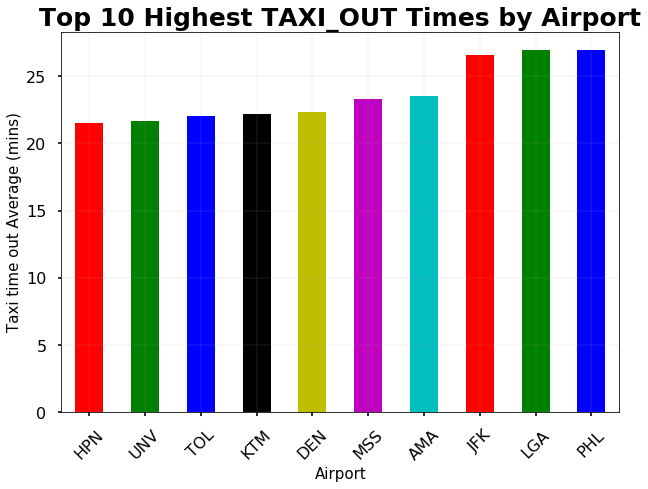

```python
# Visualization 1:

top10_TAXI_OUT = top10_TAXI_OUT.sort_values('TAXI_OUT')

figure,axes = plt.subplots(figsize=(10,7))

top10_TAXI_OUT.plot(ax=axes, kind='bar', color=my_colors)

axes.set_xticks(range(0,10))
x_lab = ('HPN', 'UNV', 'TOL', 'KTM', 'DEN', 'MSS', 'AMA', 'JFK'
         , 'LGA', 'PHL')
axes.set_xticklabels(x_lab, rotation=45)

axes.get_legend().remove()
axes.set_ylabel('Taxi time out Average (mins)', fontsize=15)
axes.set_xlabel('Airport', fontsize=15)
axes.set_title('Top 10 Highest TAXI_OUT Times by Airport', fontsize=25, fontweight='bold')
axes.grid(alpha=.1)
plt.xticks(rotation=45)
```

[figure not shown]

```python
# Visualization 2:

top10_TAXI_IN = top10_TAXI_IN.sort_values('TAXI_IN')

figure,axes = plt.subplots(figsize=(10,7))

top10_TAXI_IN.plot(ax=axes, kind='bar', color=my_colors)

axes.set_xticks(range(0,10))
x_lab = ('PKC', 'MGW', 'ALO', 'CMI', 'DBQ', 'GGG', 'MQT', 'SUX'
         , 'TOL', 'TXK')
axes.set_xticklabels(x_lab, rotation=45)

axes.get_legend().remove()
axes.set_ylabel('Taxi time out Average (mins)', fontsize=15)
axes.set_xlabel('Airport', fontsize=15)
axes.set_title('Top 10 Highest TAXI_IN Times by Airport', fontsize=25, fontweight='bold')
axes.grid(alpha=.1)
```

Bonus Question:

```
Text(5,0.5,'Average Value across Airlines')
```

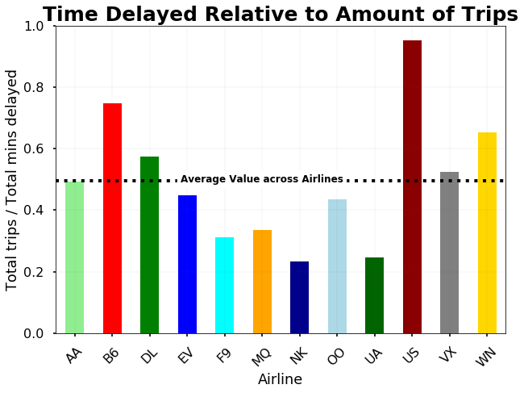

```python
sum_airlines = delay_AM_airlines['DEPARTURE_DELAY'] # total delay by each AIRLINE

airline_total_trips = flights['AIRLINE'].value_counts() # find number of trips for each airline sum_airlines

#pd.merge(sum_airlines, airline_total_trips)

result = sum_airlines.append(airline_total_trips)
result

merged = pd.concat([sum_airlines, airline_total_trips], axis=1)

relative_delayedness = merged['AIRLINE'] / merged['DEPARTURE_DELAY'] # AS is an absurd outlier and doesn't have to be in the analysis
relative_delayedness = relative_delayedness.drop(['AS', 'HA'])             # HA is also a big outlier and will be removed

figure,axes=plt.subplots(figsize=(10,7))
relative_delayedness.plot.bar(rot=45, color=['lightgreen', 'red', 'green', 'blue',
                                             'cyan', 'orange', 'darkblue',
                                            'lightblue', 'darkgreen', 'darkred',
                                            'grey', 'gold'])

plt.grid(b=True, which='major', color='#666666', linestyle='-', alpha=.05)
plt.title('Time Delayed Relative to Amount of Trips', fontsize=25, fontweight='bold')
plt.xlabel('Airline')
plt.ylabel('Total trips / Total mins delayed')
plt.axhline(y=relative_delayedness.mean() , color='black', linestyle='dotted', linewidth=4)
plt.text(5, .5, 'Average Value across Airlines', fontweight='bold',
         fontsize=12, va='center', ha='center', backgroundcolor='w')
```